# Code for reproducibility of presentation plots

Code for reproducibility of presentation plots Exam Number: B277001 2024-11-30

## International data, source: OECD

### Data load and preparation

```r
# data source: https://data-explorer.oecd.org/vis?fs[0]=Topic%2C1%7CHealth%23HEA%23%7CHealthcare%20use%23HEA_PRC%23&pg=0&fc=Topic&bp=true&snb=10&df[ds]=dsDisseminateFinalDMZ&df[id]=DSD_HEALTH_PROC%40DF_SCREEN&df[ag]=OECD.ELS.HD&df[vs]=1.1&dq=.................&pd=2010%2C&to[TIME_PERIOD]=false
overall_screening <- read.csv("data/0_screening_oecd_24112024.csv")

overall_screening %>%
  filter(DATA_SRCE == "PRG",
         #using <2015 to match the availability of OECD cancer survival data
         TIME_PERIOD < 2015) %>%
  mutate(year = as.numeric(TIME_PERIOD),
         country = factor(Reference.area),
         value = OBS_VALUE) %>%
  group_by(Cancer.site, country) %>%
  #keep countries that have  at least 12 records for the period 2000-2014 for each cancer site
  filter(length(country) >= 12) %>%
  ungroup() %>%
  #calculate slide window with 5 years lag
  mutate(value_5y = slider::slide_dbl(value, mean, .before = 4, .after = 0),
         #create a name_lab variable for plot labels
         name_lab = if_else(year == 2014, country, NA_character_)) %>%
  #filter by years matching the cancer survival records
  filter(year %in% c(2004, 2009, 2014)) -> df_plt_screening

#generate a named color vector for all countries
colour_vec_all <- met.brewer("VanGogh2", length(unique(df_plt_screening$country)))
names(colour_vec_all)<- unique(df_plt_screening$Reference.area)
```

### Data subset for breast neoplasms

```r
cancer_site = 'Malignant neoplasms of female breast'
colour_vec = colour_vec_all[as.character(unique(pull(df_plt_screening[df_plt_screening$Cancer.site == cancer_site, ],'country')))]

#
screening_breast <- df_plt_screening %>%
  filter(Cancer.site == cancer_site) %>%
  select(year, country, value_5y) %>%
  # create a composed year_country to match with mortality records
  mutate(year_country = interaction(year, country, sep = '-'))
```

### Mortality data for breast neoplasms

```r
# data source:https://data-explorer.oecd.org/vis?fs[0]=Topic%2C1%7CHealth%23HEA%23%7CHealthcare%20quality%20and%20outcomes%23HEA_HCQ%23&pg=0&fc=Topic&bp=true&snb=11&df[ds]=dsDisseminateFinalDMZ&df[id]=DSD_HCQO%40DF_CC&df[ag]=OECD.ELS.HD&df[vs]=1.0&dq=AUT%2BAUS.A.CCCLNTSR..Y_GE15._T.OBS&pd=2004%2C&to[TIME_PERIOD]=false
overall_inc_mor <- read.csv("data/1_survival_oecd_24112024.csv")

mortality_breast <- overall_inc_mor %>%
  filter(Measure == 'Breast cancer five-year net survival',
         Statistical.operation == 'Observed') %>%
  mutate(year = TIME_PERIOD,
         country = Reference.area,
         year_country = interaction(year, country, sep = '-'),
         mortality = OBS_VALUE) %>%
  select(year, country, mortality, year_country)
```

### Join screening and mortality datasets

```r
breast_join <- left_join(screening_breast,
                         mortality_breast,
                         by = 'year_country')

#get color vector for the countries represented
colour_vec <- colour_vec_all[as.character(unique(pull(breast_join,'country.x')))]
```

### Density plot Slide 2, panel B

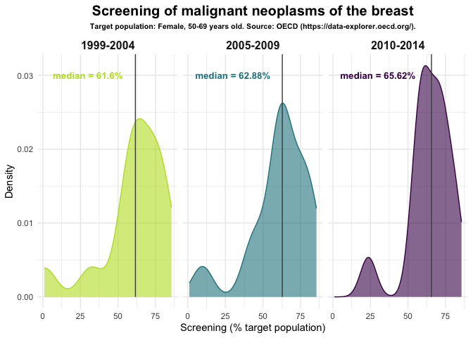

```r
screening_breast %>%
  mutate(year = case_when(year == 2004 ~"1999-2004",
                          year == 2009 ~ "2005-2009",
                          year == 2014 ~ "2010-2014"),
         year = factor(year)) %>%
  ggplot(aes(x = value_5y, color = year, fill = year)) +
  geom_density(alpha = 0.6) +
  geom_segment(data = screening_breast %>%
                 mutate(year = case_when(year == 2004 ~"1999-2004",
                                         year == 2009 ~ "2005-2009",
                                         year == 2014 ~ "2010-2014"),
                        year = factor(year)) %>%
                 group_by(year) %>%
                 summarise(median_screening = median(value_5y)) %>%
                 ungroup(),
               aes(x = median_screening,
                   xend = median_screening,
                   y = 0,
                   yend = Inf),
               colour= 'grey30')+
  geom_text(data = screening_breast %>%
              mutate(year = case_when(year == 2004 ~"1999-2004",
                                      year == 2009 ~ "2005-2009",
                                      year == 2014 ~ "2010-2014"),
                     year = factor(year)) %>%
              group_by(year) %>%
              summarise(median_screening = median(value_5y)) %>%
              ungroup(),
            aes(x = 30, y = 0.03,label = paste0('median = ',median_screening, "%")),
            fontface = 'bold',
            size = 10, size.unit = "pt") +
  scale_fill_viridis_d(direction = -1, end = 0.9) +
  scale_color_viridis_d(direction = -1, end = 0.9) +
  theme(legend.position="none") +
  labs(title = 'Screening of malignant neoplasms of the breast',
       subtitle = "Target population: Female, 50-69 years old. Source: OECD (https://data-explorer.oecd.org/).",
       x = 'Screening (% target population)',
       y = 'Density') +
  guides(fill = 'none', colour= 'none') +
  facet_wrap(.~year) +
  theme_minimal() +
  theme(strip.text = element_text(size = 12, hjust = 0.5,face = "bold"),
        plot.title = element_text(size = 15, hjust = 0.5,face = "bold"),
        plot.subtitle = element_text(size=8,hjust = 0.5,face = "bold")) -> density_breast

print(density_breast)
```

```r
#uncomment lines below for saving

# png("Rplots/density_breast.png",res = 300,units = 'in',height = 3, width = 6)
# print(density_breast)
# dev.off()
```

### Scatter and line plot Slide 2, panel C

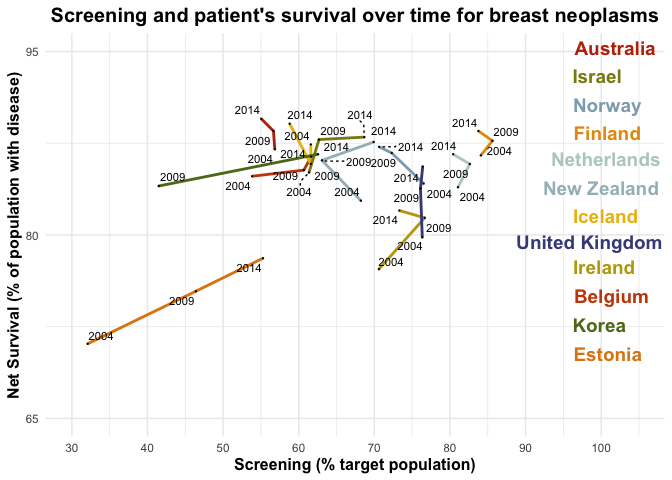

```r
breast_join %>%
  mutate(year = as.numeric(year.x)) %>%
  rename(Country = country.x,
         Screening = value_5y,
         Survival = mortality, ) %>%
  mutate(name_lab = if_else(year == 2009, Country, NA_character_)) %>%
  ggplot(aes(x= Screening, y = Survival)) +
  geom_path(aes(group = Country, colour = Country),
            alpha = 1,
            linewidth = 1,
            linejoin = 'round')+
  geom_text_repel(aes(color = Country, label = name_lab),
                  fontface = "bold",
                  size = 5,
                  direction = "y",
                  xlim = c(95, NA),
                  hjust = 0,
                  segment.size = .7,
                  segment.alpha = 0,
                  box.padding = .4,
                  segment.curvature = -0.1,
                  segment.ncp = 3,
                  segment.angle = 20)+
  geom_point(size = 0.5, shape = 16) +
  geom_text_repel(aes(label = year),
    size = 3,
    direction = "both",
    force_pull = 10,
    segment.size = 0.5,
    segment.alpha = 1,
    segment.linetype = "dotted",
    box.padding = 0.2,
    segment.curvature = -0.11,
    segment.ncp = 3,
    segment.angle = 20) +
  scale_colour_manual(values = colour_vec) +
  scale_x_continuous(limits = c(30,100),
                     breaks = seq(30,100, 10),
                     expand = expansion(mult=c(0.05,.12)))+
  scale_y_continuous(limits = c(65,95),
                     breaks = seq(65,95, 15))+
  theme_minimal() +
  labs(title = 'Screening and patient\'s survival over time for breast neoplasms',
       x = 'Screening (% target population)',
       y='Net Survival (% of population with disease)') +
  theme(plot.title = element_text(size = 15, hjust = 0.5,face = "bold"),
        plot.subtitle = element_text(size=8,hjust = 0.5,face = "bold"),
        axis.title =  element_text(size = 12, hjust = 0.5,face = "bold")) +
  guides(colour='none')-> breast_mortalityscreening

print(breast_mortalityscreening)
```

```r
#uncomment lines below for saving

# png(filename = 'Rplots/breast_plt.png',res = 300,width = 6.8, height = 5.8, units = 'in')
# print(breast_mortalityscreening)
# dev.off()
```

## Scotland data, source: Public Health Scotland

```r
#read file dictionary of health boards names and codes
# source: https://geoportal.statistics.gov.uk/documents/844159d820da487686d124a25e2eb84d/about
hb21 <- read.csv("data/2_hbscot_codes_name.csv")

#read a simple geojson to generate the map
# source: https://www.arcgis.com/apps/mapviewer/index.html?layers=52aecbed981b42e6ab4030510873e6dd
map_HB_scot <- st_read("data/3_hbscot_map.geojson")
# read mortality data Scotland per Health Board
# source: https://www.opendata.nhs.scot/dataset/cancer-mortality/resource/f0446372-e55a-441e-ae71-0b21a1cdda2c
mort <- read.csv("data/4_mortality_hbScot_24112024.csv")


# filter mortality for breast cases
mort_filter <- mort %>%
  filter(Year == '2016-2020',
         CancerSite == 'Breast',
         Sex == 'Female')

#merge mortality dataset with dictionary
mort_filter_hb21 <- merge(hb21, mort_filter, by.x = 'HB21CD', by.y = 'HB') %>%
  # adding \n so long HB names with & get split
  mutate(HB21NM = str_replace_all(HB21NM," and ", "\n & " ))

map_HB_scot. <- map_HB_scot %>%
  mutate(h06_name = str_replace_all(h06_name," & ", "\n & " ))

# merge mortality and the dataframe from the map by Health Board name
map_HBmortality_scot <- merge(map_HB_scot, mort_filter_hb21, by.x = 'h06_name', by.y = 'HB21NM')
```

### Map plot slide 4, panel A

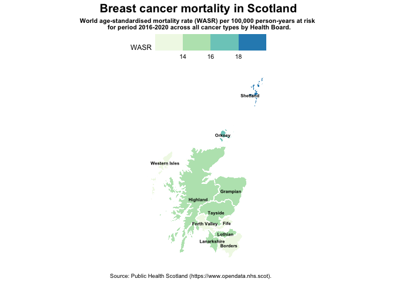

```r
# Plot with ggplot2's sf geom
ggplot(data = map_HBmortality_scot, mapping = aes(label=h06_name)) +
  #map the world-age standardised rate (WASR) of deaths
  geom_sf(aes(fill = WASR), color='white') +
  scale_fill_fermenter(direction = 1, palette = "GnBu")+
  geom_sf_text(fontface = "bold",size = 2)+
  labs(title = "Breast cancer mortality in Scotland",
       subtitle = "World age-standardised mortality rate (WASR) per 100,000 person-years at risk \n for period 2016-2020 across all cancer types by Health Board.",
       caption = "Source: Public Health Scotland (https://www.opendata.nhs.scot).") +
  theme_map()+
  theme(
    legend.position = "top",
    legend.justification = 0.5,
    legend.key.size = unit(0.75, "cm"),
    legend.key.width = unit(1.0, "cm"),
    legend.text = element_text(size = 8),
    legend.margin = margin(),
    plot.title = element_text(size = 15, hjust = 0.5,face = "bold"),
    plot.subtitle = element_text(size=8,hjust = 0.5,face = "bold")
  )-> breast_map

print(breast_map)
```

```r
#uncomment lines below for saving
# png("Rplots/map_breast_scot.png",res = 300,units = 'in',height = 6, width = 5)
# print(breast_map)
# dev.off()
```

### Breast screening in Scotland. Figure slide 4, panel B

```r
# data load and wrangling
#data source:
screening_scotland <- read_excel("data/5_screening_hbscot_2223.xlsx")
hb_names <- str_replace_all(map_HB_scot.$h06_name, '\n', '')

colour_vec_hb <- met.brewer("VanGogh2", length(hb_names))
names(colour_vec_hb)<- hb_names

#add color black for national level screening rates
colour_vec_hb_scot = c(colour_vec_hb,  setNames("black", "Scotland"))
#define line type vector, segmented for national level
lty_hb_scot <- c(rep(1, length(hb_names)), 2)
names(lty_hb_scot)<- names(colour_vec_hb_scot)
```

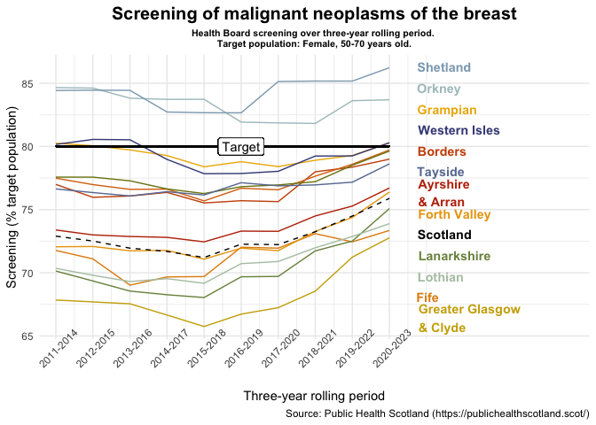

```r
screening_scotland %>%
  select(`Scottish Breast Screening Programme`:...12) %>%
  filter(`Scottish Breast Screening Programme` %in% c(hb_names, "Scotland","NHS Board of Residence")) %>%
  row_to_names(row_number = 1) %>%
  select(where( ~!all(is.na(.x)))) %>%
  pivot_longer(names_to = "Period",
               cols = `2011/14`:`2020/23`,
               values_to = 'Uptake') %>%
  rename(hb_name = `NHS Board of Residence`) %>%
  separate_wider_delim(Period,"/", names = c(NA, "Period")) %>%
mutate(Uptake = as.numeric(Uptake),
       Period = as.numeric(Period),
       hb_name = factor(hb_name),
       hb_name_label = ifelse(Period == 23, as.character(hb_name), NA_character_),
       #hb_name_label = str_replace_all(hb_name_label, "&", "\n&")
       ) %>% #View()
  ggplot(aes(Period, Uptake, group = hb_name,
             linetype = hb_name,
             label = hb_name_label)) +
  geom_line(aes(colour = hb_name))+
  geom_text_repel(aes(label = str_replace_all(hb_name_label, "&", "\n&"),
                      colour = hb_name_label),
                  fontface = "bold",
                  size = 3.8,
                  direction = "y",
                  segment.alpha = 0,
                  xlim = c(23.5, NA),
                  hjust = 0,
                  box.padding = .45) +
  scale_colour_manual(values = colour_vec_hb_scot)+
  scale_linetype_manual(values = lty_hb_scot) +
  #show target screenign rate at 80%
  geom_segment(aes(x = 14, xend = 23, y = 80, yend = 80), colour= 'black') +
  geom_label(aes(x = 19, y=80, label="Target"), fill='white') +
  scale_x_continuous(expand=expand_scale(mult=c(0.05,.6)),
                     labels = paste0("20",seq(11,20),"-20",seq(14,23)),
                     breaks = seq(14,23)) +
  guides(colour = 'none', linetype = 'none')+
  labs(title = 'Screening of malignant neoplasms of the breast',
       subtitle = "Health Board screening over three-year rolling period. \nTarget population: Female, 50-70 years old.",
       caption = "Source: Public Health Scotland (https://publichealthscotland.scot/)",
       y = 'Screening (% target population)',
       x = 'Three-year rolling period') +
  theme_minimal() +
  theme(plot.title = element_text(size = 15, hjust = 0.5,face = "bold"),
        plot.subtitle = element_text(size = 8,hjust = 0.5,face = "bold"),
        axis.text.x = element_text(angle = 45)) -> scot_screen_breast

print(scot_screen_breast)
```

```r
#uncomment next lines for saving

# png("Rplots/screening_breast_scot.png",res = 300,units = 'in',height = 8, width = 8)
# print(scot_screen_breast)
# dev.off()
```

### Annex: Session info

**R version 4.4.1 (2024-06-14)**

**Platform:** aarch64-apple-darwin20

**locale:** en_US.UTF-8||en_US.UTF-8||en_US.UTF-8||C||en_US.UTF-8||en_US.UTF-8

**attached base packages:** *stats*, *graphics*, *grDevices*, *utils*, *datasets*, *methods* and *base*

**other attached packages:** *tidyselect(v.1.2.1)*, *stringr(v.1.5.1)*, *slider(v.0.3.2)*, *skimr(v.2.1.5)*, *sf(v.1.0-19)*, *readxl(v.1.4.3)*, *readr(v.2.1.5)*, *prettydoc(v.0.4.1)*, *plotly(v.4.10.4)*, *patchwork(v.1.3.0)*, *pander(v.0.6.5)*, *MetBrewer(v.0.2.0)*, *janitor(v.2.2.0)*, *gt(v.0.11.1)*, *ggthemes(v.5.1.0)*, *ggrepel(v.0.9.6)*, *ggpubr(v.0.6.0)*, *ggplot2(v.3.5.1)*, *tidyr(v.1.3.1)*, *dplyr(v.1.1.4)*, *bookdown(v.0.41)* and *pacman(v.0.5.1)*

**loaded via a namespace (and not attached):** *viridisLite(v.0.4.2)*, *farver(v.2.1.2)*, *warp(v.0.2.1)*, *fastmap(v.1.2.0)*, *lazyeval(v.0.2.2)*, *digest(v.0.6.37)*, *timechange(v.0.3.0)*, *lifecycle(v.1.0.4)*, *magrittr(v.2.0.3)*, *compiler(v.4.4.1)*, *rlang(v.1.1.4)*, *sass(v.0.4.9)*, *tools(v.4.4.1)*, *utf8(v.1.2.4)*, *yaml(v.2.3.10)*, *data.table(v.1.16.2)*, *knitr(v.1.49)*, *ggsignif(v.0.6.4)*, *labeling(v.0.4.3)*, *htmlwidgets(v.1.6.4)*, *classInt(v.0.4-10)*, *RColorBrewer(v.1.1-3)*, *xml2(v.1.3.6)*, *repr(v.1.1.7)*, *abind(v.1.4-8)*, *KernSmooth(v.2.23-24)*, *withr(v.3.0.2)*, *purrr(v.1.0.2)*, *grid(v.4.4.1)*, *fansi(v.1.0.6)*, *e1071(v.1.7-16)*, *colorspace(v.2.1-1)*, *scales(v.1.3.0)*, *cli(v.3.6.3)*, *rmarkdown(v.2.29)*, *generics(v.0.1.3)*, *rstudioapi(v.0.16.0)*, *httr(v.1.4.7)*, *tzdb(v.0.4.0)*, *DBI(v.1.2.3)*, *cachem(v.1.1.0)*, *proxy(v.0.4-27)*, *cellranger(v.1.1.0)*, *base64enc(v.0.1-3)*, *vctrs(v.0.6.5)*, *jsonlite(v.1.8.9)*, *carData(v.3.0-5)*, *car(v.3.1-3)*, *hms(v.1.1.3)*, *rstatix(v.0.7.2)*, *Formula(v.1.2-5)*, *jquerylib(v.0.1.4)*, *units(v.0.8-5)*, *glue(v.1.8.0)*, *lubridate(v.1.9.3)*, *stringi(v.1.8.4)*, *gtable(v.0.3.6)*, *munsell(v.0.5.1)*, *tibble(v.3.2.1)*, *pillar(v.1.9.0)*, *htmltools(v.0.5.8.1)*, *R6(v.2.5.1)*, *evaluate(v.1.0.1)*, *backports(v.1.5.0)*, *broom(v.1.0.7)*, *snakecase(v.0.11.1)*, *bslib(v.0.8.0)*, *class(v.7.3-22)*, *Rcpp(v.1.0.13-1)*, *xfun(v.0.49)* and *pkgconfig(v.2.0.3)*